# A knowledge-based risk mapping tool for cost estimation of international construction projects - ScienceDirect

- [View **PDF**](https://www.sciencedirect.com/science/article/pii/S0926580514000624/pdfft?md5=dff2fbc318a5c9e33363f8927743ad80&pid=1-s2.0-S0926580514000624-main.pdf)

## [Automation in Construction](https://www.sciencedirect.com/journal/automation-in-construction)

[Volume 43](https://www.sciencedirect.com/journal/automation-in-construction/vol/43/suppl/C), July 2014, Pages 144-155

# A knowledge-based risk mapping tool for cost estimation of international construction projects

https://doi.org/10.1016/j.autcon.2014.03.010[Get rights and content](https://s100.copyright.com/AppDispatchServlet?publisherName=ELS&contentID=S0926580514000624&orderBeanReset=true)

## Highlights

- •

  Consideration of interdependencies among risks is necessary.
- •

  A computerized tool is needed to support different risk management stages.
- •

  The incorporation of a lessons learned database can minimize subjectivity.
- •

  Inconsistencies between risk ratings still exist due to different risk perceptions.
- •

  The findings of case study and usability test show that the tool is successful.

## Abstract

Effective risk assessment and management is critical for success in international construction projects. This paper proposes a knowledge-based risk mapping tool for systematically assessing risk-related variables that may lead to cost overrun in international markets. The tool uses an ontology that relates risk and vulnerability to cost overrun [1] and a novel risk-vulnerability assessment methodology [2] to estimate potential risk paths that may emerge in international construction projects. The tool has been developed in collaboration with an industrial partner, a construction management company that gives risk management consultancy services to Turkish contractors working in international markets. The tool has been designed by using the previous projects of the partner firm as test cases and preferences of company professionals are taken into account while determining the functions of the tool. As the reliability and usability of the tool significantly depend on the subjective evaluations of users about level of vulnerability and magnitude of potential risk events, a lessons learned database has been incorporated into the tool so that decision-makers may refer to risk event histories of previous projects to make estimations about forthcoming projects. In order to evaluate the usability of the tool, a usability test has been conducted by eight construction experts. Usability test results demonstrated that the tool can be utilized for prediction of probable risk paths and their impact on cost. Results of a case study, a building project in Serbia, have also been reported in this paper to demonstrate the functions and the performance of the tool. Although the usability and reliability test results are satisfactory, the tool should be seen as an initial platform which should be improved by increasing its “intelligence” by high quality and enough number of risk event histories, and also customized according to user preferences as well as company policies.

## Keywords

Risk management

International construction

Risk mapping

Lessons learned database

## 1. Introduction

Internationalization of construction industry resulted in a more complex web of project organizations necessitating a systematic, comprehensive and proactive management of risk. The ISO Guide 73 on risk management vocabulary defines “risk management process” as systematic application of management policies, procedures and practices to the activities of communicating, consulting and establishing the context, and identifying, analyzing, evaluating, treating, monitoring and reviewing risk [3]. “Establishing the context” as stated in this definition covers the identification of external and internal parameters to be taken into account when managing risk and setting the scope and risk criteria for the [risk management policy](https://www.sciencedirect.com/topics/engineering/risk-management-policy). Establishing the context covers determination of the knowledge sources as risk management should be based on best available knowledge. In this paper, a knowledge-based risk mapping tool that uses the best available knowledge within the company and helps the decision-makers to establish the context for management of risk during international construction projects will be introduced.

Risk assessment is a vital part of risk management. Within the construction management literature, various techniques and tools are proposed for systematic assessment of risk. However, their practical use has been limited. First of all, risk assessment mostly covers preparation of risk checklists and assigning subjective risk ratings to individual risk factors. Risk checklists ignore interdependencies among risk factors and neglect the emergence of risk paths rather than individual risk factors. Such checklists “stay at a simple level of detail” to prioritize the risks [4], cannot prevent ambiguity about the type of risk [5] and cannot distinct risk sources and their consequences [6]. In construction management literature, authors such as Refs. [4], [6], [7], [8], [9], [10], [11] have pinpointed the importance of causalities among risk items and proposed the construction of cause–effect diagrams, knowledge maps, influence diagrams, or risk paths to demonstrate “causal relations”. Moreover, as the project outcomes are affected by the “combination” of various interdependent risk factors as well as cause–effect relationships between them, the “risk paths” should be considered during risk assessment rather than individual risk factors [2]. Moreover, risk assessment practices involve high level of subjectivity due to their reliance solely on intuition, judgment or individual experience of decision-makers when making predictions about probability of occurrence of risks and their impacts on project goals. Also, the risk management paradigms exist only as methodologies whereas decision support systems that utilize these methodologies are quite limited [12].

In this study, it is hypothesized that a knowledge-based risk assessment methodology which considers the causal relations among risk variables and vulnerabilities of the project environment may be used to support risk-related decision-making in practice. The objective of this study is to develop a risk mapping tool for systematically assessing interdependent risk-related variables and vulnerabilities that may lead to cost overrun in international markets. The risk-vulnerability ontology reported in Fidan et al. [1] and a novel SEM-based risk assessment methodology proposed in Eybpoosh et al. [2] constitute the foundation of this study. Given that the vulnerabilities are defined by the user, the tool is used to calculate magnitude of risk events, identify potential risk paths, draw the project's risk map and estimate the level of cost overrun. A lessons learned database, in which experiences of construction experts about cause–effect relations among risk-related variables in previous projects can be stored, has been also incorporated into the tool. The tool may be used to develop an organizational memory on risk-related factors and aid to implement a knowledge-based approach for risk management.

## 2. Research background

In this section, previous studies on risk identification and assessment methods as well as computer-based risk management support tools are overviewed and their limitations are discussed.

Risk identification is the initial step of [risk management process](https://www.sciencedirect.com/topics/engineering/risk-management-process). Companies usually utilize generic risk checklists and breakdown structures for this purpose. Within the literature, various risk checklists and risk breakdown structures are proposed to identify and classify risk factors. Perry and Hayes [13] identified 29 major sources of risks and classified them under the categories of “physical”, “environmental”, “design”, “logistics”, “financial”, “legal”, “political”, “construction” and “operation”. Mustafa and Al-Bahar [14] identified 32 risk factors, grouped them under six categories, and measured the risk level of an international construction project using the [Analytical Hierarchy Process](https://www.sciencedirect.com/topics/engineering/analytical-hierarchy-process) (AHP). The construction risk management system (CRMS), developed by Al-Bahar and Crandall [15], incorporates an influence-diagramming technique to identify the risk-related factors and Monte Carlo Simulation to analyze project risks. Zhi [16] defined probable risks in international construction projects according to their “sources” such as “nation/region”, “construction industry”, “company” and “project”. The ICRAM-1 model developed by Hastak and Shaked [17] is a systematic approach to quantify risk items in international projects in which the authors defined 73 tangible and intangible risk items under three categories; macro (country), market and project levels. The relation between the risk and cost performance of projects has also been investigated by various authors. Baloi and Price [18] identified global risk factors affecting cost performance of international construction projects, classified them under seven main categories, and utilized fuzzy decision framework to assess the impact of the identified factors on cost. Idrus et al. [19] developed a model that utilizes [fuzzy expert system](https://www.sciencedirect.com/topics/engineering/fuzzy-expert-system) during the risk assessment process and quantifies the level of contingency.

Decision-makers indispensably rely on intuition, judgment and individual experience during risk assessment. Lack of precise and [generic data](https://www.sciencedirect.com/topics/engineering/generic-data) to assess risk level of a project usually leads to inconsistencies and vagueness in risk ratings. However, although the construction industry is project-based and each project is unique, some of the knowledge gained in a project may be transferred to forthcoming projects, in case the acquired knowledge is codified and stored properly [20], [21], [22]. Within the current literature, there is a consensus that knowledge gained in previous projects can be reused in the forthcoming projects to enhance decision making process when carrying out risk assessment. To demonstrate how learning-based risk management can be achieved in practice, Dikmen et al. [22] developed a tool where risk-related information are defined, stored and updated in the form of a lessons learned database. A web-based system, “Knowledge Platform for Contractors (KPfC)”, developed by Kıvrak et al. [20], allows capturing the [tacit knowledge](https://www.sciencedirect.com/topics/engineering/tacit-knowledge) (i.e. know how, expert recommendations) as well as explicit knowledge (i.e. documents, reports) which can be utilized in forthcoming projects. Lin et al. [23] proposed a “Map-Based Knowledge Management” system to enable knowledge transfer between the projects.

Within the literature, various authors have highlighted the importance of computer-based tools and systems in improving the effectiveness and acceptability of risk management activities. Various authors (i.e. [24], [25]) suggested the use of computerized tools or models for cost estimation purposes by claiming that traditional risk assessment methodologies suffer from excessive time requirements. Akintoye and MacLeod [26] summarized superiorities of computer-based tools over traditional risk assessment methods as; (1) traditional methods carry out assessment in a deterministic way and they fail to cover consecutive nature of construction industry, (2) computer-based tools can deal with dynamic and uncertain environment of construction industry that enable decision-makers to update their plans as project progress. Al-Zarooni and Abdou [27] claimed that the utilization of information technology (IT) and computer-based tools would assist in “facilitating and widening the use of risk management as a decision making tool in the construction industry”.

With the rising importance of computer-based tools, several researchers and institutions have tried to develop software engineering integrated risk management tools and systems. The risk assessor model (RAM), developed by Jannadi and Almishari [24], is one of these efforts. RAM is a computer-based tool that measures the degree of risk evolved in a particular construction activity. Touran and Lopez [28] developed a model by utilizing @Risk to assess the effects of cost escalation factors on large construction projects. Dikmen et al. [29] developed a company-specific risk assessment tool that incorporates a generic risk model and a fuzzy risk assessment methodology to quantify level of cost overrun in international projects. The assessment model developed by Fung et al. [30] is another support system that is used for safety management practices of construction industry that may be used to predict the level of safety risk. Carr and Tah [10] developed a prototype system that incorporates a fuzzy approach for risk assessment as well as facilitates case-based reasoning to assist users by capturing, re-using, and comparing risk-related knowledge. CIRIA Riskcom, developed by Hall et al. [31], is a spreadsheet-based software tool that is used to carry out risk identification, assessment, mitigation and monitoring throughout the supply chain of construction projects. Although, the tool relies on the judgments of the users on “likelihood” and “consequence” of risk factors; when quantifying the overall risk rating of projects, authors recommended that knowledge gained from past projects shall be used to support decisions in the future. Hsueh et al. [32] developed an on-line multi-criteria risk assessment model to evaluate risks of joint ventures operating in China by using the Analytical Hierarchy Process (AHP) and the Utility Theory. The model integrates World Wide Web (WWW) that facilitates Enterprise Knowledge Portal (EKP) and the company database to carry out an on-line evaluation process. FIRMS (Fully Integrated Risk Management System) developed by Han et al. [4] is another web-based decision support system that can be used during various phases of international construction projects. The system incorporates a bid-decision model, a profit prediction model, and a risk scenario analysis and contract management guideline as well as a database of 126 overseas projects and a list of interrelated risk attributes.

Consequently, the necessity of a knowledge-based system for risk assessment and computerized tools to facilitate risk management processes is frequently highlighted within the literature.

## 3. Research objective

This paper presents the findings of a two-year research project entitled as “Development of a Knowledge-Based Risk Mapping Tool for International Construction Projects”. The project was sponsored by Ministry of Science, Industry and Technology of Turkey and carried out in collaboration with an industrial partner which is a medium-large scale construction management company. The main objective of this study was to develop a knowledge-based risk mapping tool in the light of the experiences and suggestions of the industrial partner. The company aims to use the tool to provide risk management consultancy service to its international clients.

Slovic et al. [33] argue that risk is dealt with in 3 fundamental ways: risk as feelings (instinctive and intuitive reactions to danger), risk as analysis (logic, reason and scientific deliberation) and risk as politics (when the previous two clash). After discussing the Epstein's dual process theory, “experiential system”, “analytical system” and the importance of “affect” in decision-making, authors point out that the experiential mode of thinking and analytical mode of thinking are continually active and interactive. They conclude “while we may be able to do the right thing without analysis, it is unlikely that we can employ analytic thinking rationally without guidance from affect somewhere along the line.” The tool developed in this research project is based on the same idea that decision-makers should employ affect beneficially in risk analysis. Thus, although the tool uses an analytical approach for risk mapping, it is based on risk event histories/narratives that are incorporated into the tool by the company professionals.

## 4. Research methodology

As stated earlier, the risk-vulnerability ontology reported in Fidan et al. [1] and risk map structure proposed in Eybpoosh et al. [2] constitute the foundation of this study. Fidan et al. [1] identified probable risk-related variables of international construction projects using the data of Turkish contractors doing business abroad. Authors classified the variables as “vulnerability”, “risk source”, “risk event” and “risk consequence” and constructed an ontology that relates risk items and vulnerabilities to cost overrun. Based on this ontology, Eybpoosh et al. [2] identified 36 interrelated risk paths that may emerge in international construction projects using the data of 166 projects carried out by Turkish contractors in international markets. Eybpoosh et al. [2] utilized Structural Equation Modeling (SEM) to calculate the interdependency coefficients between risk-related factors and the impact of each risk path on project cost overrun. The vulnerabilities as defined in Eybpoosh et al. [2] are depicted in Table 1. After the level of vulnerability is assessed by assigning ratings to each of the sources of vulnerability, the interdependency coefficients found as a result of SEM can be used to predict cost overrun in international construction projects.

Table 1. Vulnerability sources.

| Vulnerability | No | Vulnerability source |
| --- | --- | --- |
| Adverse country related conditions | VS1 | Instability of economic conditions |
|  | VS2 | Instability of government |
|  | VS3 | Instability of international relations |
|  | VS4 | Social unrest |
|  | VS5 | High level of bureaucracy |
|  | VS6 | Immaturity of legal system |
|  | VS7 | Restrictions for foreign companies |
|  | VS8 | Unavailability of local material |
|  | VS9 | Unavailability of equipment and machinery |
|  | VS10 | Unavailability of local labor |
|  | VS11 | Unavailability of local subcontractor |
|  | VS12 | Unavailability of infrastructure |
| Project complexity | VS13 | Complexity of design |
|  | VS14 | Poor constructability |
|  | VS15 | Complexity of construction method |
| Uncertainty of geological problems | VS16 | Uncertainty of geotechnical investigation |
| Strict requirements | VS17 | Strict quality requirements |
|  | VS18 | Strict environmental requirements |
|  | VS19 | Strict health & safety requirements |
|  | VS20 | Strict project management requirements |
| Contract specific problems | VS21 | Vagueness of contract clauses |
|  | VS22 | Contract errors |
| Engineer's incompetency | VS23 | Technical incompetency of engineer |
|  | VS24 | Managerial incompetency of engineer |
|  | VS25 | Engineer's lack of financial resources |
| Client's incompetency | VS26 | Client's unclear objectives |
|  | VS27 | Client's high level of bureaucracy |
|  | VS28 | Client's negative attitude |
|  | VS29 | Client's poor staff profile |
|  | VS30 | Client's lack of financial resources |
|  | VS31 | Client's technical incompetency |
|  | VS32 | Client's poor managerial/organizational abilities |
| Adverse site conditions | VS33 | Poor site supervision |
|  | VS34 | Lack of site facilities |
| Contractor's lack of experience | VS35 | Contractor's lack of experience in similar projects |
|  | VS36 | Contractor's lack of experience in the country |
|  | VS37 | Contractor's lack of experience about the project delivery system |
|  | VS38 | Contractor's lack of experience with client |
| Contractor's lack of resources | VS39 | Contractor's lack of financial resources |
|  | VS40 | Contractor's lack of technical resources |
|  | VS41 | Contractor's lack of staff |
| Contractor's lack of managerial skills | VS42 | Poor project scope management |
|  | VS43 | Poor project time management |
|  | VS44 | Poor project cost management |
|  | VS45 | Poor project quality management |
|  | VS46 | Poor human resource management |
|  | VS47 | Poor communication management |
|  | VS48 | Poor risk management |
|  | VS49 | Poor procurement management |

The risk map structure used in the tool has been constructed based on the results of SEM. Bentler [34] described SEM as a collection of statistical techniques (i.e. confirmatory factor analysis, path analysis and multiple regression analysis) that allows the representation and measurement of possible direct and indirect [interrelationships](https://www.sciencedirect.com/topics/engineering/interrelationship) among variables. The hypothesized conceptual model of SEM is composed of a measurement model and a construct model. In order to examine the reliability and the validity of the model (the risk map structure) “internal consistency of constructs”, “convergent validity”, “discriminant validity” tests have been utilized [2]. “Internal consistency of constructs” measures reliability of a model and tests “unidimensionality” and “individual item reliability”. Factor loadings measured in the study of Eybpoosh [35] satisfy the condition of unidimensionality with values greater than 0.5 which was recommended in Hair et al. [36]. All observed variables possess a sufficient degree of individual reliability having “Cronbach's Alpha” coefficients greater than the threshold value of 0.7 which was recommended in Nunally [37] and Hair et al. [36]. “Average variance extracted” is a metric used to measure convergent validity. The measurement model has a sufficient degree of convergent validity with “average variance extracted” higher than 50%. The model also satisfies the discriminant validity as shared variance among distinct constructs is less than the average variance shared among the construct and its indicators. Furthermore, in order to evaluate whether the risk-path construct model can be statistically identified or not, Eybpoosh [35] facilitated Bentler and Weeks' method [38] in which all variables are considered either Independent (IV) or Dependent (DV). Benter [34] proposed that degrees of freedom of the variables should have a positive value that is known data points should be larger than the unknown parameters, in order to develop an identified model. The risk-path construct model developed by Eybpoosh [35] was over-identified, with 244 “number of unknown parameters”, 3403 “data point” and 3159 “degrees of freedom”. In order to measure the validity of the risk-path construct model and the fit and suitability of the assumed causal relationships to the actual data, Eybpoosh [35] used 4 distinct indices; “Comparative Fit Index” (CFI), “Non-Normed Fit Index” (NNFI), “Room [Mean Square Error](https://www.sciencedirect.com/topics/engineering/mean-square-error) of Approximation” (RMSEA) and the ratio of “CHI-Square” to the “Degree of Freedom” (*x*<sup>2</sup>/DF). The test results confirmed that the sample data can be adequately represented by the construct model and the hypothesized causal relations were also confirmed. As the risk map structure and the reliability of the assessment method were statistically confirmed, the aim of the current study is not to prove the reliability of the risk mapping technique, but to develop a software using this technique and test its usability.

In this current research project, the tool has been developed in three major steps as; planning and preparation, development, testing and validation. In the first step, the “context” and knowledge requirements of the tool have been questioned by an extensive literature review and discussions held with partner company experts. Literature survey covers mainly the “expectations from risk management support tools”. Interviews with the partner company experts facilitated understanding of the requirements of the industry to facilitate risk management in practice. One of the major findings from the interviews is that assistance is needed during the assignment of risk ratings. A database which captures and stores lessons learned from previous projects and enables learning from previous projects to support decision making in forthcoming projects is needed. In addition, partner company experts stressed that construction professionals may not have enough knowledge about what is covered under the term “vulnerability” and may assume different meanings under the same “vulnerability” factor which may lead to significant inconsistencies in the assigned ratings. Thus, it is concluded that some kind of assistance is also needed to ensure a common understanding about vulnerability sources. It is decided that the attributes under each vulnerability factor should be defined to eliminate potential misunderstandings.

This study adopts a case study approach to develop a prototype lessons learned database by conducting several face-to face interviews and review sessions with partner company experts. Real risk event histories of previous projects (that are called as project cases) are captured by interviews and risk-related information is stored in the database. To systemize the process, a set of structured questions are prepared. The questions are divided into three sets that explore “knowledge about the project portfolio”, “knowledge about the project case” and “knowledge about project case attributes”. In the first set, experts are requested to explain the projects and give brief information about generic project attributes such as country name, project type and contract type. Within the context of the second set, four questions; ‘what actually happened in the project (risk event)’, ‘what are the triggering sources that affected the occurrence of these events (risk source)’, ‘what are the consequences of these events on project goals (risk consequence)’ as well as ‘what are the project and organizational vulnerabilities that initiated/impacted the risk paths’, have been asked. Finally, three questions such as ‘why the identified vulnerabilities exist (vulnerability source)’, ‘how the existence of the vulnerability sources affected the project (consequence)’ and ‘in what extent the existence of vulnerability sources resulted in the specified consequence (rating)’ have been asked. The responses of the company professionals form the basis of the prototype database. 32 different risk event histories from 13 real construction projects are collected, reviewed and stored in the prototype database based on the identified risk-related information. An example about the risk event histories is given in Table 2.

Table 2. An example about the risk event histories.

| Project information Project ID | Project information Duration | Project information Year | Project information Country | Project information Budget | Project information Type |
| --- | --- | --- | --- | --- | --- |
| 8 | 26 months | 2004 | Poland | 30,000,000 € | Fast tram project |

[output not shown]

| Case summary Vulnerability factor | Case summary Vulnerability source | Case summary Rating | Case summary Consequence |
| --- | --- | --- | --- |
| Strict requirements | Strict environmental requirements | 4 | Delay |

Note: The risk ratings are defined using a 1–5 Likert scale where 1, 2, 3, 4 and 5 denote very low, low, medium, high and very high risk levels, respectively.

In this study, “attributes” are defined to explain or measure vulnerability. They denote the conditions or circumstances that should be considered while assessing the level of vulnerability. Attributes and their descriptions are defined as a result of an extensive literature review. After close examination of the 58 journal papers and 9 text books, 303 attributes associated with 49 vulnerability sources are identified. The case studies provided by the partner firm revealed that the identified attributes are meaningful and applicable in real construction projects. As a further attempt, a review session is conducted by partner company experts to discuss in what extent the identified attributes can represent the characteristics of associated vulnerability sources. Even though company experts made some minor changes and added some missing attributes, they justified that given attributes and their descriptions can effectively be used to assess magnitude of vulnerability. The final framework of attributes is fed into the tool in order to be used during the vulnerability assessment process.

At the second step of the research, the required functions of the tool are determined. Tool interfaces are designed considering the steps of the SEM-based risk assessment process and knowledge-based risk management system. At the final step, a laboratory test has been conducted as well as a case study to test the tool's performance and usability.

## 5. Knowledge-based risk mapping tool

### 5.1. Architecture and fundamentals of the tool

The proposed tool has been developed using Microsoft Visual C Sharp and operates under all versions of Microsoft Windows. The tool operates with a main window (user interface) that controls the features of the tool. It directs users to seven functions which are; operations about the project (i.e. add new project), operations about cases (i.e. add new case), risk map generation, risk assessment, report generation, sensitivity analysis and it has a help function. The ‘project information interface’ allows the entry of a new project to the tool. ‘Add new case’ interface is enabled to capture and codify risk event histories in order to develop organizational lessons learned database. The ‘risk map’ interface operates under a single interface; however it is interlinked with ‘attribute analysis/rating’ and ‘lessons learned database’ interfaces. Fig. 1 shows the snapshot taken from the risk map interface. Blue colored boxes represent vulnerabilities and they are interconnected with ‘Vulnerability Source Assessment’ interface which directs users to either “attribute analysis/rating” or “lessons learned database”. Finally, risk sources and events are represented in green whereas risk consequence, which is cost overrun, is represented in red boxes. A case library is designed to store the projects and associated cases that have been entered into the lessons learned database previously.

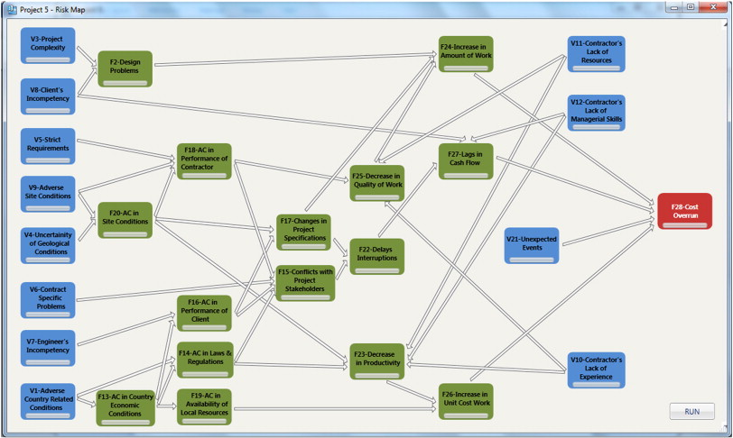

1. [Download : Download full-size image](https://ars.els-cdn.com/content/image/1-s2.0-S0926580514000624-gr1.jpg)

Fig. 1. Risk map structure.

The proposed tool can be used to conduct sensitivity analysis after an initial risk assessment exercise. Sensitivity analysis is carried out to quantify changes in the level of cost overrun percentage with respect the changes in the magnitudes of vulnerability sources. Moreover, an automatic report generation system is structured to facilitate documentation and sharing of risk assessment results.

### 5.2. Framework of risk management process

The knowledge-based risk management process model is given in Fig. 2. The proposed tool employs a risk management workflow composed of five major phases; risk identification, risk assessment, risk evaluation and response, risk handling and monitoring and finally, risk review and documentation.

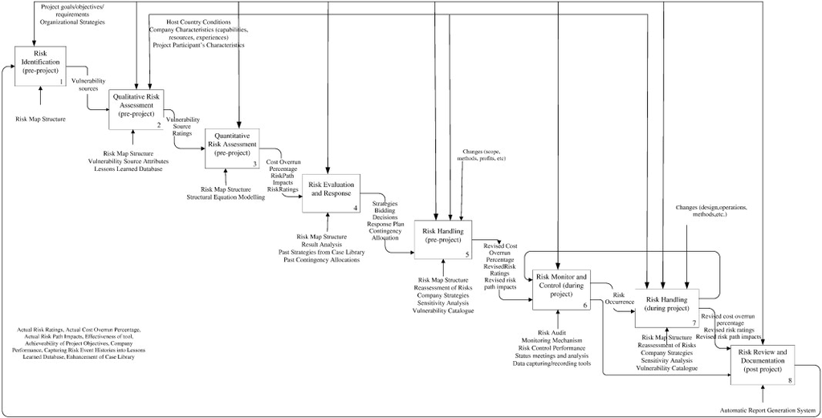

1. [Download : Download full-size image](https://ars.els-cdn.com/content/image/1-s2.0-S0926580514000624-gr2.jpg)

Fig. 2. Process model.

#### 5.2.1. Risk identification

The first stage of the risk management process is the identification of risk-related variables that may emerge in international construction projects. The risk path structure comprises of vulnerability, risk source, risk event and risk consequence chains as well as vulnerability source-attributes. The underlying assumption of the proposed risk path structure is that vulnerabilities trigger the occurrence of risk sources and risk sources lead to risk consequence through the occurrence of risk events. Attributes, as was introduced in the previous section, represent the conditions/factors that should be considered during assessment of the vulnerability sources.

#### 5.2.2. Risk assessment

Qualitative risk assessment is the second stage where magnitudes of vulnerability sources are assigned by the decision makers. In this stage, decision makers should assess the magnitude of each vulnerability source shown on the risk map structure. A screenshot of the vulnerability assessment interface is given in Fig. 3. Vulnerability assessment can be carried out by using two alternative methods; “attribute rating (AR)” or “utilization of the lessons learned database (LL)”. If AR option is selected, the attributes associated with the vulnerability are listed, attribute weights are defined (equal weights can be assumed, default weights of the tool can be used or user may assign weights himself), ratings are defined for each attribute using 1–5 Likert scale and weights are automatically multiplied with ratings to calculate an overall vulnerability rating/magnitude. Decision makers can also utilize the lessons learned database to determine magnitude of vulnerabilities, then they choose LL option. If LL option is selected, cases related to the selected vulnerability source are automatically retrieved from the database. The decision makers can filter the retrieved cases with respect to project type, duration, country, year and/or budget. Moreover, they can search a keyword and keywords that are found within the cases can be highlighted. After the vulnerability ratings are entered, the tool automatically calculates the magnitudes of the other risk-related variables using the coefficients (strength of causal relations) as found by SEM. Consequently, the risk consequence, which is “cost overrun” is automatically calculated.

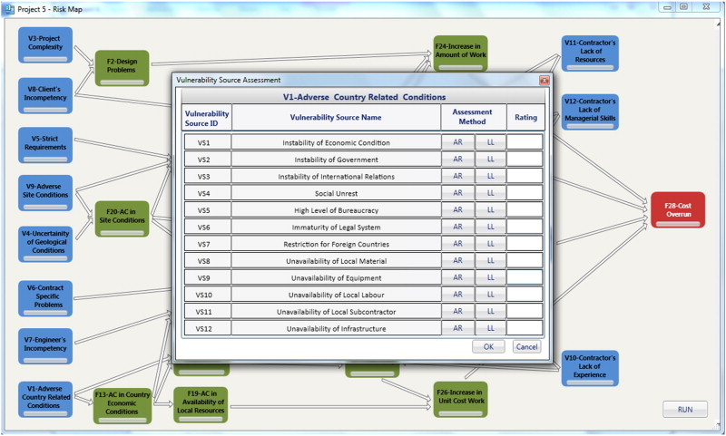

1. [Download : Download full-size image](https://ars.els-cdn.com/content/image/1-s2.0-S0926580514000624-gr3.jpg)

Fig. 3. Vulnerability source assessment.

#### 5.2.3. Risk evaluation and response

Risk evaluation and response is the fourth stage of the risk management process where the findings of the risk assessment process are evaluated. The tool allows the evaluation of risk assessment results in three groups; risk rating results, risk path results and cost overrun results. Risk rating results list the magnitudes of the risk-related variables in 1–5 Likert scale. Risk path results give an overall list of risk paths resulting in cost overrun and their impact on the cost overrun percentage. Finally, cost overrun results represent the probable cost overrun percentage, the five most critical risk paths having the highest contribution to cost overrun and the impact of these paths on cost overrun percentage. These results can be used by the decision makers to formulate response strategies. Lessons learned database can also be utilized in this stage to retrieve previously implemented response strategies and contingency decisions so that appropriate actions can be determined.

#### 5.2.4. Risk handling and monitoring

During risk handling, some mitigation actions can be defined to eliminate critical vulnerabilities. Sensitivity analysis can be utilized in this stage to find out the most significant vulnerabilities that highly contribute to project cost overrun. At the end of risk handling, vulnerability ratings/magnitudes can be revised, risks can be reassessed and revised cost overrun ratings can be determined. Monitoring risks is mainly about capturing risk events that actually occur during the project by conducting site audits or status meetings. Risk monitoring is critical for formation of the lessons learned database.

#### 5.2.5. Risk review and documentation

Final phase of the process model is the risk review and documentation at the post project appraisal stage where actual risk ratings and cost overrun percentage are recorded. The risk event histories happened in the project are captured and stored in the lessons learned database to improve organizational risk memory. The documented risk event histories can be shared and transferred within the organization by using an automatic report generation system.

### 5.3. Features and expected benefits of the tool

The expected benefits of the tool can be summarized as follows;

- 1.

  Systematic risk identification and classification: The most common problem of risk management practices in pre-project stage is the insufficient risk identification practices [39]. The risk map offered in this study provides an effective way to visualize risk-related variables and risk paths that may emerge in international markets.
- 2.

  Guidance on risk assessment: It is believed that the reliability of outcomes of risk assessment is highly dependent on how the risks are analyzed and how their probable magnitudes are predicted. In this study, the underlying methodology of the risk assessment process is that the magnitudes of vulnerability sources are assessed by decision makers and the tool automatically quantifies the magnitudes of all other variables by utilizing the coefficients found by SEM. Risk event histories of previous projects that have been captured, codified, and stored within the database may also be used during decision making. It is hypothesized by the authors that, although subjectivity involved in the prediction process cannot be fully avoided due to different risk perceptions and attitudes of decision makers, it can be minimized by additional assistance.
- 3.

  Guidance on different phases of project: The tool can be utilized in different stages of a project; bid evaluation and preparation, contracting, construction, post project commission and evaluation. Construction practitioners can use the tool in the earlier stages of a project such as [feasibility studies](https://www.sciencedirect.com/topics/engineering/feasibility-study), bidding decisions, bid preparations, risk identification and cost estimation. In construction and operation stages, tool can be utilized to assess in what extent an adverse change in project environment or performances of participants can influence cost performance of the project. In post-project phase, the risk-related knowledge gained throughout the project can be captured and stored.
- 4.

  Development of an organizational risk memory: The lessons learned database, the case library and automatic report generation system of the proposed tool can further be used to develop an organizational risk memory in which risk-related knowledge of previous projects is stored, documented and shared among organization members. It may avoid the loss of knowledge through retirement or resignation of project experts, or spread of project team members over the organization after the execution of projects [20], [25], [40]. The proposed tool allows the documentation of risk events throughout the progress of projects. The database enables capturing causalities among risks rather than acquiring the simple and obvious facts. By examination of their triggering factors, reoccurrence of similar risks, mistakes or pitfalls can be minimized or at least appropriate [mitigation strategies](https://www.sciencedirect.com/topics/engineering/mitigation-strategy) can be implemented. The automatic report generation system allows knowledge sharing among individuals.

## 6. Usability testing

Usability is “the extent to which a product can be used by specified users to achieve specified goals with effectiveness, efficiency and satisfaction in a specified context of use” [41]. It is perceived as a major driver for the acceptability of computer-based systems and services [42] and critical success factor for their sustainability in the market [43]. Testing the usability of a system is a systematic and repetitive process through which specific usability goals and characteristics are defined, and those characteristics are quantitatively or qualitatively measured to evaluate whether the system achieves the pre-defined usability goals. Within the literature, various usability testing methodologies have been offered whereas the most widely used ones are; field testing, laboratory testing, surveys, focus groups, thinking aloud sessions, and questionnaires. In this study, laboratory testing coupled with a session audit and questionnaire sessions is conducted to ascertain that the proposed tool can be used effectively and efficiently as well as to capture feedback of tool users about the tool's performance. In this effort, some quantitative and qualitative objectives are determined, usability measures are defined to represent these objectives, and usability benchmarks are estimated to evaluate whether the tool achieves the identified objectives. Moreover, as the usability is “too abstract term to study directly” and has been used with different meanings [44], [45], seven usability attributes (ease of use, effectiveness, satisfaction, consistency, learnability, user guidance and error rate) are defined to address overall usability level of the tool. Table 3 represents the summary of usability testing methodology along with the usability attributes and measurement techniques associated with the quantitative and qualitative test objectives.

Table 3. The summary of usability testing methodology.

| Test objective | Usability attributes | Measurement technique | Description |
| --- | --- | --- | --- |
| Quantitative objectives | Ease of use, effectiveness, learnability | Laboratory testing | Tobii Software records the usability measures and eye tracks of participants. |
|  | Ease of use, user guidance | Session audit | Test facilitator records number of “help use” of each participant. |
| Qualitative objectives | Error rate | Session audit | Test facilitator records user problems during laboratory testing sessions. |
|  | Ease of use, satisfaction, consistency, learnability, user guidance | Post-task questionnaire | Participants fill out a questionnaire after they complete the given tasks. |
|  | Satisfaction | Post-test questionnaire | Participants fill out a questionnaire after they complete all tasks. |

Based on the major functions of the proposed tool, nine test scenarios and associated tasks are defined during laboratory testing. The nine scenarios are created to test the ease of creating a project, assigning attribute weights, using different attribute rating methods, using the lessons learned database, risk assessment by using the risk map, evaluation of results, sensitivity analysis, defining new cases and searching the case library to find relevant cases. Same test scenarios are distributed to the test participants to keep consistency of the test and the same project data is given. The test participants have been selected considering the target population and a pre-test questionnaire has been conducted to understand the level of experience of the participants. Two different categories were identified as “experienced” and “less experienced” considering the participants' computer usage skills and risk assessment experience. A detailed training session about risk assessment and the risk mapping tool was organized for the less experienced group.

A checklist is prepared to capture and manually keep the track of problems that the participants encountered in testing sessions. The checklist is further used by test facilitator when auditing the laboratory testing sessions. Post-test and post-task questionnaires are prepared with the usability attributes which are filled out by test participants when they conducted each task and the whole test. The questionnaires are prepared by modifying the standard questionnaires that are proposed by various authors [46], [47], [48]. Prior to the usability testing, a pilot testing is conducted by test facilitator to evaluate whether the test scenarios are appropriate and questionnaires are suitable. The findings of the pilot study are further be used to determine usability benchmarks. The benchmarks, measurement techniques and usability measures are presented in Table 4.

Table 4. The usability benchmarks.

| Usability attribute | Measurement technique | Usability measures | Usability benchmarks Best estimate | Usability benchmarks Acceptable level |
| --- | --- | --- | --- | --- |
| Ease of use | Laboratory testing | Completion rate | – | 100% |
| Effectiveness | Laboratory testing | Total visit duration | 673.98 s | 1347.96 s |
| Ease of use | Laboratory testing | Mouse click count | 237 | 474 |
| Ease of use | Sessions audit | Help use | – | 30% |
| Error rate | Sessions audit | Error rate | – | – |
| Ease of use | Post-task questionnaire | 1–5 Likert scale | – | 4 |
| Satisfaction | Post-task questionnaire | 1–5 Likert scale | – | 4 |
| Consistency | Post-task questionnaire | 1–5 Likert scale | – | 4 |
| Learnability | Post-task questionnaire | 1–5 Likert scale | – | 4 |
| User guidance | Post-task questionnaire | 1–5 Likert scale | – | 4 |
| Satisfaction | Post-test questionnaire | Verbal statements | – | – |

The laboratory testing took place at METU Computer Center, Human Computer Interaction Research and Application Laboratory. The laboratory is accredited with the “TS EN ISO/IEC 9241-151 [Ergonomics](https://www.sciencedirect.com/topics/engineering/ergonomics) of Human–System Interaction” and “ISO/IEC 17025 General Requirements for the Competence of Testing and Calibration Laboratories”. During the laboratory testing, two camera recorders, an eye tracker (Tobii T120), a test computer and Tobii Studio are used. The eye trackers collect the visual data of test participants such as where the participant looks on the screen, how long a fixation is and how much time the participant looks at a certain point. The eye movements of participants are recorded by Tobii T120 and analyzed with Tobii Studio Software. Eight test participants are involved in usability testing process who are graduate students at METU and also work as professionals in the construction sector.

Two quantitative metrics can be obtained from laboratory testing; total visit duration and mouse click counts taken in each test scenario. The descriptive statistics taken from the Tobii Studio Software represented that average visit durations and mouse click counts of participants in each scenario are less than the predefined usability benchmarks (as given in Table 4). Moreover, test facilitator observed that each participant has successfully completed all test scenarios given to them. Except one participant, the ‘help use’ levels of all participants are less than the acceptable level. The most frequently occurred problems when using the tool are about defining attribute weights and utilizing case library. However, these problems are not critical as the findings of the experienced participants revealed that after a single tool use session it will be easy to carry out these operations. Also, eye tracks of participants are visualized as gaze plots and heat maps with the use of Tobii Studio Software. The heat maps revealed that accumulated fixation of participants focused mostly around the targeted regions, the regions that one should look at when conducting test scenarios. The participant responses captured by post-task and post-test questionnaires demonstrated that the proposed tool is satisfactory. The responses of participants regarding the usability attributes and the associated test scenarios are given in Table 5. The findings of the post-task questionnaires reveal that the most critical scenario of the test is Scenario 4, which is the use of lessons learned database interface. Also, test participants evaluated the most critical usability attributes as ease of use and learnability. However, the findings given in Table 5 still represent that the ratings of the each usability attribute as well as the overall applicability of test scenarios are higher than the predefined usability benchmarks.

Table 5. The summary of post-task questionnaires.

| Scenario/attribute | Ease of use | Satisfaction | Consistency | Learnability | User guidance | Scenario overall |
| --- | --- | --- | --- | --- | --- | --- |
| Scenario 1 | 4.56 | 4.38 | 4.41 | 4.28 | 4.69 | 4.45 |
| Scenario 2 | 4.33 | 4.38 | 4.5 | 4.31 | 4.67 | 4.44 |
| Scenario 3 | 4.48 | 4.71 | 4.72 | 4.5 | 4.81 | 4.64 |
| Scenario 4 | 4.02 | 4 | 4.69 | 4.04 | 4.68 | 4.29 |
| Scenario 5 | 4.69 | 4.56 | 4.69 | 4.56 | 4.63 | 4.63 |
| Scenario 6 | 4.47 | 4.41 | 4.78 | 4.5 | 4.75 | 4.58 |
| Scenario 7 | 4.74 | 4.67 | 4.72 | 4.85 | 4.75 | 4.74 |
| Scenario 8 | 4.58 | 4.78 | 4.7 | 4.65 | 4.88 | 4.72 |
| Scenario 9 | 4.53 | 4.81 | 4.59 | 4.68 | 4.89 | 4.7 |
| Attribute overall | 4.49 | 4.52 | 4.64 | 4.49 | 4.75 | 4.58 |

The “best features” the tool have been stated as “tool interfaces are esthetically pleasing”, “carrying out risk assessment is extremely easy” and “automatic functions (i.e. sensitivity analysis) of the tool are useful”. On the other hand; participants found keyboard shortcuts insufficient, data entry was found difficult and some abbreviations were confusing. However, they were either ‘extremely satisfied’ or ‘very satisfied’ about the tool performance.

## 7. Case study

The reliability of the proposed tool is tested on a real construction project which was carried out by one of the leading Turkish construction companies doing business in international markets. The company employs over 3000 people at 93 completed and 28 on-going national and international construction projects. By utilizing its 36-years' experience, the company successfully provides construction services including construction of infrastructure, agriculture, energy, building, housing, and industrial facility projects. The case study project is construction of an embassy building in Serbia. It was the company's first job in Serbia; however they have completed several embassy building projects at different countries previously. The project started on August 2009, and had a scheduled duration of 36 months. It is a large-size project having a contract price around 125,000,000 $. The contract type is design build (DB) and the payment type is lump sum. The company takes its role as a joint venture partner in the project whereas the client is the Serbian government.

A face-to-face interview and a tool use session were conducted with a company expert. The company expert is knowledgeable about company practices and had an active role throughout the execution of the case study project. The interview and tool use session lasted about 2 h. At the start of the interview, the tool was introduced, its major functions were demonstrated, and the objective of the study was explained to the expert. During the interview, the expert was requested to give information about the sample project, state the risks that occurred during the execution of the project, and indicate the actual cost overrun percentage. In tool use sessions, the expert was requested to evaluate the vulnerability sources and associated attributes that existed in the project. Finally, the expert was asked to comment on the idea of “transferring risk related knowledge” to forthcoming projects by utilizing risk event histories and lessons learned database.

The verbal analysis of the case study about the vulnerabilities and their associated sources and attributes are maintained and recorded during tool use sessions. It is elaborated from the verbal statements of the expert that complexity of design and strict quality, and security requirements imposed by the client are the most significant problems leading to cost overrun. It took considerable time to complete the design of the project and to take design approval from client representatives. Materials and equipment were mostly imported from abroad; however there were several flaws during the procurement and delivery of these resources.

In addition to the analysis of attributes, the expert utilized lessons learned database when predicting the magnitudes of significant vulnerability sources (i.e. complexity of design). For example, 3 similar project histories (project cases) were retrieved from the database about complexity of design. The snapshot showing retrieved project cases from the lessons learned database is given in Fig. 4.

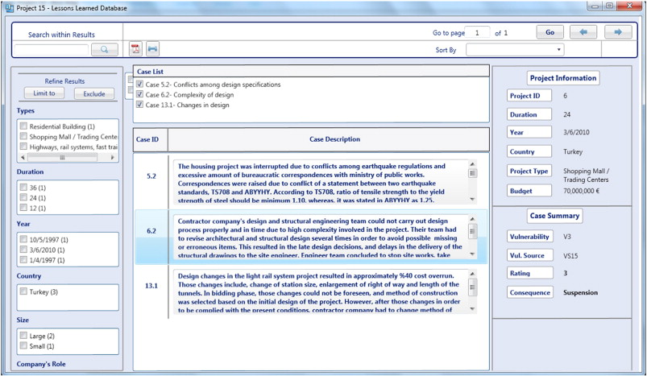

1. [Download : Download full-size image](https://ars.els-cdn.com/content/image/1-s2.0-S0926580514000624-gr4.jpg)

Fig. 4. Lessons learned database.

Fig. 5 represents a snapshot about risk assessment results of the case study. The cost overrun percentage quantified by the tool is 10% whereas the actual percentage defined by the project expert is 7%. The expert was satisfied with the result given by the tool and stressed that, due to excessive approval procedures, extensive design reviews, and strict and complex project requirements, the actual cost overrun could be higher than 7% in practice. Experience on similar projects, relations with the client, experience on design-build projects, enough financial resources, managerial skills and triple management system (i.e. ISO 9001, ISO 14001, BS-OHSAS 18001) appear as the factors that help the company to manage risks and/or eliminate some of the vulnerabilities in this project. The case study project revealed the importance of consideration of vulnerabilities (such as company strengths and weaknesses) when making predictions about risk level of projects. The expert also mentioned that organizations and companies should create and improve their own knowledge assets by utilizing learning-based mechanisms and databases as defined in the tool. He also stated that the tool is easy to use, esthetically pleasing, and provides valuable guidance for risk management which is not common in the construction industry.

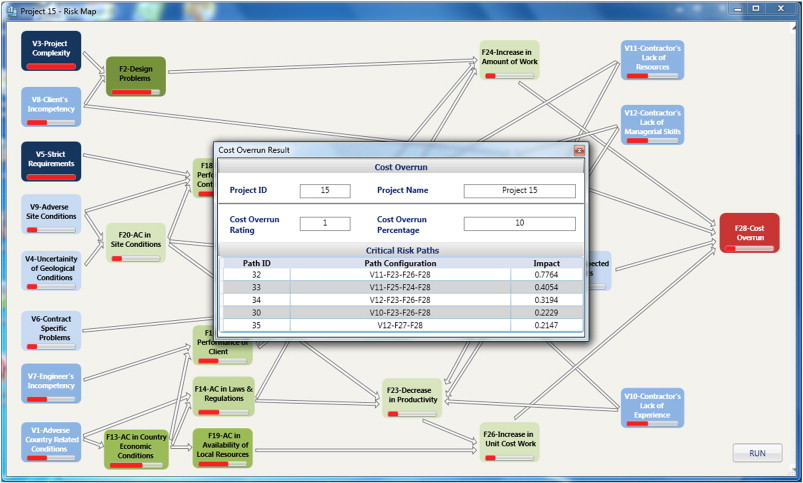

1. [Download : Download full-size image](https://ars.els-cdn.com/content/image/1-s2.0-S0926580514000624-gr5.jpg)

Fig. 5. Risk assessment results.

## 8. Conclusions

Based on the previous studies on risk paths and knowledge-based risk assessment, this study aims to propose a tool for risk assessment of international construction projects that considers causalities among risk-related variables, impacts of risk paths and lessons learned from previous projects. The risk mapping tool provides a virtual platform for the assessment of the project vulnerabilities and identification of risk paths leading to cost overrun especially during the initial stages of a project, and storing of risk-related knowledge during and after the project to ensure effective communication and management of risks.

Although the usability test results and findings from the case study point out that the tool can be successfully used in practice, there are some shortcomings that should also be noted about its reliability. First of all, the data used to construct the tool is based on data gathered from the Turkish contractors (166 international projects) working abroad and the coefficients used during prediction of the cost overrun reflect the case of Turkish contractors. Thus, its results may not be applicable and reliable for other contractors. Moreover, the performance of the tool significantly depends on the knowledge sources of the company and the quality of the lessons learned database. To improve the quality of risk ratings as defined by the user and increase the reliability of the predictions of cost overrun, the lessons learned database should be constructed in such a way that it includes enough number of cases and critical information such as the cause and effect relations between risk-related factors. The tool should be seen as an initial platform which can be improved by company feedback and its performance can be enhanced by increasing its “intelligence” by increased knowledge sources fed into it.

Although, different methods are incorporated into the tool to help decision-makers in defining risk ratings, it is clear that inconsistencies between ratings of different decision-makers can still exist, as the tool does not have the capability to consider “risk perceptions”, “fuzziness” or explore risks as “feelings” and “politics”. Authors believe that more research is necessary to incorporate the company-level policies, company's risk appetite and also potential opportunities as well as threats during the risk assessment process.

## Acknowledgment

This paper presents the findings of the two-year research project entitled “Development of a Knowledge-Based Risk Mapping Tool for International Construction Projects” sponsored by the Ministry of Science, Industry and Technology under the grant number 00681.STZ.2010-2.

## References

1. [1]

   G. Fidan, I. Dikmen, A.M. Tanyer, M.T. Birgonul

   Ontology for relating risk and vulnerability to cost overrun in international projects

   J. Comput. Civ. Eng., 25 (4) (2011), pp. 302-315

   [View in Scopus](https://www.scopus.com/inward/record.url?eid=2-s2.0-79960258110&partnerID=10&rel=R3.0.0)Google Scholar
2. [2]

   M. Eybpoosh, I. Dikmen, M.T. Birgonul

   Identification of risk paths in international construction projects using structural equation modeling

   J. Constr. Eng. Manag., 137 (12) (2011), pp. 1164-1175

   [View in Scopus](https://www.scopus.com/inward/record.url?eid=2-s2.0-84855944211&partnerID=10&rel=R3.0.0)Google Scholar
3. [3]

   International Organization for Standardization

   ISO Guide 73, Risk Management—Vocabulary

   (2009)

   [Google Scholar](https://scholar.google.com/scholar_lookup?title=ISO%20Guide%2073%2C%20Risk%20ManagementVocabulary&publication_year=2009&author=International%20Organization%20for%20Standardization)
4. [4]

   S.H. Han, D.Y. Kim, H. Kim, W.S. Jang

   A web-based integrated system for international project risk management

   Autom. Constr., 17 (2008), pp. 342-356

   [View PDF](https://www.sciencedirect.com/science/article/pii/S0926580507000751/pdfft?md5=305c765487a3beff3919516972ebb1ca&pid=1-s2.0-S0926580507000751-main.pdf)[View article](https://www.sciencedirect.com/science/article/pii/S0926580507000751)[View in Scopus](https://www.scopus.com/inward/record.url?eid=2-s2.0-37549017361&partnerID=10&rel=R3.0.0)Google Scholar
5. [5]

   S.C. Ward

   Assessing and managing important risks

   Int. J. Proj. Manag., 17 (6) (1999), pp. 331-336

   [View PDF](https://www.sciencedirect.com/science/article/pii/S0263786398000519/pdfft?md5=739820c9a13a5cec917bc4c7ea89c333&pid=1-s2.0-S0263786398000519-main.pdf)[View article](https://www.sciencedirect.com/science/article/pii/S0263786398000519)[View in Scopus](https://www.scopus.com/inward/record.url?eid=2-s2.0-0032595613&partnerID=10&rel=R3.0.0)[Google Scholar](https://scholar.google.com/scholar_lookup?title=Assessing%20and%20managing%20important%20risks&publication_year=1999&author=S.C.%20Ward)
6. [6]

   R.J. Chapman

   The controlling influences of effective risk identification and assessment for construction design management

   Int. J. Proj. Manag., 19 (3) (2001), pp. 147-160

   [View PDF](https://www.sciencedirect.com/science/article/pii/S0263786399000708/pdfft?md5=91b665c5f3efa5e30b80f88a681347c5&pid=1-s2.0-S0263786399000708-main.pdf)[View article](https://www.sciencedirect.com/science/article/pii/S0263786399000708)[View in Scopus](https://www.scopus.com/inward/record.url?eid=2-s2.0-0035313962&partnerID=10&rel=R3.0.0)Google Scholar
7. [7]

   D.B. Ashley, J.J. Bonner

   Political risks in international construction

   J. Constr. Eng. Manag., 113 (3) (1987), pp. 447-467

   [View in Scopus](https://www.scopus.com/inward/record.url?eid=2-s2.0-0023421720&partnerID=10&rel=R3.0.0)[Google Scholar](https://scholar.google.com/scholar_lookup?title=Political%20risks%20in%20international%20construction&publication_year=1987&author=D.B.%20Ashley&author=J.J.%20Bonner)
8. [8]

   P.X.W. Zou, G. Zhang, J. Wang

   Understanding the key risks in construction projects in China

   Int. J. Proj. Manag., 25 (2007), pp. 601-614

   [View PDF](https://www.sciencedirect.com/science/article/pii/S0263786307000488/pdfft?md5=426f387adf9ed4f468bfd58cf28aa9ff&pid=1-s2.0-S0263786307000488-main.pdf)[View article](https://www.sciencedirect.com/science/article/pii/S0263786307000488)[View in Scopus](https://www.scopus.com/inward/record.url?eid=2-s2.0-34447566136&partnerID=10&rel=R3.0.0)[Google Scholar](https://scholar.google.com/scholar_lookup?title=Understanding%20the%20key%20risks%20in%20construction%20projects%20in%20China&publication_year=2007&author=P.X.W.%20Zou&author=G.%20Zhang&author=J.%20Wang)
9. [9]

   B. Akinci, M. Fischer

   Factors affecting contractors' risk of cost overburden

   J. Manag. Eng., 14 (1) (1998), pp. 67-76

   [View in Scopus](https://www.scopus.com/inward/record.url?eid=2-s2.0-0031705846&partnerID=10&rel=R3.0.0)[Google Scholar](https://scholar.google.com/scholar_lookup?title=Factors%20affecting%20contractors%20risk%20of%20cost%20overburden&publication_year=1998&author=B.%20Akinci&author=M.%20Fischer)
10. [10]

    V. Carr, J.H.M. Tah

    A fuzzy approach to construction project risk assessment and analysis: construction project risk management system

    Adv. Eng. Softw., 32 (2001), pp. 847-857

    [View PDF](https://www.sciencedirect.com/science/article/pii/S0965997801000369/pdfft?md5=c2d7010a4f2baa75e706bbb2873a2cf7&pid=1-s2.0-S0965997801000369-main.pdf)[View article](https://www.sciencedirect.com/science/article/pii/S0965997801000369)[View in Scopus](https://www.scopus.com/inward/record.url?eid=2-s2.0-0035476791&partnerID=10&rel=R3.0.0)Google Scholar
11. [11]

    P.K. Dey

    Managing project risk using combined analytic hierarchy process and risk map

    Appl. Soft Comput., 10 (2010), pp. 990-1000

    [View PDF](https://www.sciencedirect.com/science/article/pii/S1568494610000761/pdfft?md5=b3080a0fe18a250dd3dc9aae3f653d64&pid=1-s2.0-S1568494610000761-main.pdf)[View article](https://www.sciencedirect.com/science/article/pii/S1568494610000761)[View in Scopus](https://www.scopus.com/inward/record.url?eid=2-s2.0-78049263856&partnerID=10&rel=R3.0.0)[Google Scholar](https://scholar.google.com/scholar_lookup?title=Managing%20project%20risk%20using%20combined%20analytic%20hierarchy%20process%20and%20risk%20map&publication_year=2010&author=P.K.%20Dey)
12. [12]

    I. Dikmen, M.T. Birgonul, A.E. Arikan

    A critical review of risk management support tools

    20th Annual ARCOM Conference, Association of Researchers in Construction Management, 2, Heriot Watt University (September 1–3 2004), pp. 1145-1154
13. [13]

    J.G. Perry, R.W. Hayes

    Risk and its management in construction projects

    Proc. Inst. Civ. Eng., 78 (1985), pp. 499-521

    [CrossRef](https://doi.org/10.1680/iicep.1985.859)[View in Scopus](https://www.scopus.com/inward/record.url?eid=2-s2.0-0022080070&partnerID=10&rel=R3.0.0)[Google Scholar](https://scholar.google.com/scholar_lookup?title=Risk%20and%20its%20management%20in%20construction%20projects&publication_year=1985&author=J.G.%20Perry&author=R.W.%20Hayes)
14. [14]

    M.A. Mustafa, J.F. Al-Bahar

    Project risk assessment using the analytic hierarchy process

    IEEE Trans. Eng. Manag., 38 (1) (1991), pp. 46-52

    [View in Scopus](https://www.scopus.com/inward/record.url?eid=2-s2.0-0026106979&partnerID=10&rel=R3.0.0)[Google Scholar](https://scholar.google.com/scholar_lookup?title=Project%20risk%20assessment%20using%20the%20analytic%20hierarchy%20process&publication_year=1991&author=M.A.%20Mustafa&author=J.F.%20Al-Bahar)
15. [15]

    J.F. Al-Bahar, K.C. Crandall

    Systematic risk management approach for construction projects

    J. Constr. Eng. Manag., 116 (3) (1990), pp. 533-546

    [View in Scopus](https://www.scopus.com/inward/record.url?eid=2-s2.0-0025491311&partnerID=10&rel=R3.0.0)[Google Scholar](https://scholar.google.com/scholar_lookup?title=Systematic%20risk%20management%20approach%20for%20construction%20projects&publication_year=1990&author=J.F.%20Al-Bahar&author=K.C.%20Crandall)
16. [16]

    H. Zhi

    Risk management for overseas construction projects

    Int. J. Proj. Manag., 13 (4) (1995), pp. 231-237

    [View PDF](https://www.sciencedirect.com/science/article/pii/026378639500015I/pdf?md5=f6ff579079399081a2f264e999dd5758&pid=1-s2.0-026378639500015I-main.pdf)[View article](https://www.sciencedirect.com/science/article/pii/026378639500015I)[View in Scopus](https://www.scopus.com/inward/record.url?eid=2-s2.0-0011127465&partnerID=10&rel=R3.0.0)[Google Scholar](https://scholar.google.com/scholar_lookup?title=Risk%20management%20for%20overseas%20construction%20projects&publication_year=1995&author=H.%20Zhi)
17. [17]

    B.M. Hastak, A. Shaked

    ICRAM-1: model for international construction risk assessment

    J. Manag. Eng., 16 (1) (2000), pp. 59-69

    [View in Scopus](https://www.scopus.com/inward/record.url?eid=2-s2.0-0033689577&partnerID=10&rel=R3.0.0)[Google Scholar](https://scholar.google.com/scholar_lookup?title=ICRAM-1%3A%20model%20for%20international%20construction%20risk%20assessment&publication_year=2000&author=B.M.%20Hastak&author=A.%20Shaked)
18. [18]

    D. Baloi, A.D.F. Price

    Modeling global risk factors affecting construction cost performance

    Int. J. Proj. Manag., 21 (2003), pp. 261-269

    [View PDF](https://www.sciencedirect.com/science/article/pii/S0263786302000170/pdfft?md5=ff824202d33cf36ba6d8e3c4c42650a4&pid=1-s2.0-S0263786302000170-main.pdf)[View article](https://www.sciencedirect.com/science/article/pii/S0263786302000170)[View in Scopus](https://www.scopus.com/inward/record.url?eid=2-s2.0-0037402597&partnerID=10&rel=R3.0.0)[Google Scholar](https://scholar.google.com/scholar_lookup?title=Modeling%20global%20risk%20factors%20affecting%20construction%20cost%20performance&publication_year=2003&author=D.%20Baloi&author=A.D.F.%20Price)
19. [19]

    A. Idrus, M.F. Nuruddin, M.A. Rohman

    Development of project cost contingency estimation model using risk analysis and fuzzy expert system

    Expert Syst. Appl., 38 (2011), pp. 1501-1508

    [View PDF](https://www.sciencedirect.com/science/article/pii/S0957417410006895/pdfft?md5=7764070fc2e6eaa23639da052d43a011&pid=1-s2.0-S0957417410006895-main.pdf)[View article](https://www.sciencedirect.com/science/article/pii/S0957417410006895)[View in Scopus](https://www.scopus.com/inward/record.url?eid=2-s2.0-78049531038&partnerID=10&rel=R3.0.0)Google Scholar
20. [20]

    S. Kıvrak, G. Arslan, I. Dikmen, M.T. Birgonul

    Capturing knowledge in construction projects: knowledge platform for contractors

    J. Manag. Eng., 24 (2) (2008), pp. 87-95

    [View in Scopus](https://www.scopus.com/inward/record.url?eid=2-s2.0-40849092924&partnerID=10&rel=R3.0.0)Google Scholar
21. [21]

    H.P. Tserng, S.Y.L. Yin, R.J. Dzeng, B. Wou, M.D. Tsai, W.Y. Chen

    A study of ontology-based risk management framework of construction projects through project life cycle

    Autom. Constr., 18 (2009), pp. 994-1008

    [View PDF](https://www.sciencedirect.com/science/article/pii/S0926580509000855/pdfft?md5=0eae0ba32837cc3062a5a41626a15660&pid=1-s2.0-S0926580509000855-main.pdf)[View article](https://www.sciencedirect.com/science/article/pii/S0926580509000855)[View in Scopus](https://www.scopus.com/inward/record.url?eid=2-s2.0-68049123109&partnerID=10&rel=R3.0.0)Google Scholar
22. [22]

    I. Dikmen, M.T. Birgonul, C. Anac, J.H.M. Tah, G. Aouad

    Learning from risks: a tool for post-project risk assessment

    Autom. Constr., 18 (2008), pp. 41-50

    Google Scholar
23. [23]

    Y.C. Lin, L.C. Wang, H.P. Tserng

    Enhancing knowledge exchange through web map-based knowledge management system in construction: lessons learned in Taiwan

    Autom. Constr., 15 (2006), pp. 693-705

    [View PDF](https://www.sciencedirect.com/science/article/pii/S0926580505001317/pdfft?md5=c4791c72c74009d4626968613e408849&pid=1-s2.0-S0926580505001317-main.pdf)[View article](https://www.sciencedirect.com/science/article/pii/S0926580505001317)[View in Scopus](https://www.scopus.com/inward/record.url?eid=2-s2.0-33748179321&partnerID=10&rel=R3.0.0)Google Scholar
24. [24]

    O.A. Jannadi, S. Almishari

    Risk assessment in construction

    J. Constr. Eng. Manag., 129 (5) (2003), pp. 492-500

    [View in Scopus](https://www.scopus.com/inward/record.url?eid=2-s2.0-13944263258&partnerID=10&rel=R3.0.0)[Google Scholar](https://scholar.google.com/scholar_lookup?title=Risk%20assessment%20in%20construction&publication_year=2003&author=O.A.%20Jannadi&author=S.%20Almishari)
25. [25]

    H.M. Leung, K.B. Chuah

    A knowledge-based system for identifying potential project risks

    Int. J. Manag. Sci., 26 (5) (1998), pp. 623-638

    [View PDF](https://www.sciencedirect.com/science/article/pii/S0305048398000103/pdfft?md5=4cba1ca24061f7ac5ed48c219fc6e601&pid=1-s2.0-S0305048398000103-main.pdf)[View article](https://www.sciencedirect.com/science/article/pii/S0305048398000103)[View in Scopus](https://www.scopus.com/inward/record.url?eid=2-s2.0-0012093932&partnerID=10&rel=R3.0.0)[Google Scholar](https://scholar.google.com/scholar_lookup?title=A%20knowledge-based%20system%20for%20identifying%20potential%20project%20risks&publication_year=1998&author=H.M.%20Leung&author=K.B.%20Chuah)
26. [26]

    A.S. Akintoye, M.J. MacLeod

    Risk analysis and management in construction

    Int. J. Proj. Manag., 15 (1) (1997), pp. 31-38

    [View PDF](https://www.sciencedirect.com/science/article/pii/S026378639600035X/pdf?md5=b3c75709a1bdde562733be279c4cb22c&pid=1-s2.0-S026378639600035X-main.pdf)[View article](https://www.sciencedirect.com/science/article/pii/S026378639600035X)[View in Scopus](https://www.scopus.com/inward/record.url?eid=2-s2.0-0031079503&partnerID=10&rel=R3.0.0)[Google Scholar](https://scholar.google.com/scholar_lookup?title=Risk%20analysis%20and%20management%20in%20construction&publication_year=1997&author=A.S.%20Akintoye&author=M.J.%20MacLeod)
27. [27]

    S. Al-Zarooni, A. Abdou

    Risk management in pre-design stage and its potential benefits for UAE public projects, 28th World Congress on Housing Challenges for the 21st Century, 15–19 April

    (2000), pp. 109-118

    Abu Dhabi, UAE

    Google Scholar
28. [28]

    A. Touran, R. Lopez

    Modeling cost escalation in large infrastructure projects

    J. Constr. Eng. Manag., 132 (8) (2006), pp. 853-860

    [View in Scopus](https://www.scopus.com/inward/record.url?eid=2-s2.0-33746190783&partnerID=10&rel=R3.0.0)[Google Scholar](https://scholar.google.com/scholar_lookup?title=Modeling%20cost%20escalation%20in%20large%20infrastructure%20projects&publication_year=2006&author=A.%20Touran&author=R.%20Lopez)
29. [29]

    I. Dikmen, M.T. Birgonul, S. Han

    Using fuzzy risk assessment to rate cost overrun risk in international construction projects

    Int. J. Proj. Manag., 25 (2007), pp. 497-505

    Google Scholar
30. [30]

    I.W.H. Fung, V.W.Y. Tam, T.Y. Lo, L.L.H. Lu

    Developing a risk assessment model for construction safety

    Int. J. Proj. Manag., 28 (2010), pp. 593-600

    [View PDF](https://www.sciencedirect.com/science/article/pii/S0263786309001082/pdfft?md5=aa7cf03294c7bd07b48bf8bd9ed81f62&pid=1-s2.0-S0263786309001082-main.pdf)[View article](https://www.sciencedirect.com/science/article/pii/S0263786309001082)[View in Scopus](https://www.scopus.com/inward/record.url?eid=2-s2.0-77953360445&partnerID=10&rel=R3.0.0)Google Scholar
31. [31]

    J.W. Hall, I.C. Cruickshank, P.S. Godfrey

    Software-supported risk management for the construction industry

    Proc. ICE Civ. Eng., 144 (2001), pp. 42-48

    [View in Scopus](https://www.scopus.com/inward/record.url?eid=2-s2.0-2142651311&partnerID=10&rel=R3.0.0)Google Scholar
32. [32]

    S.L. Hsueh, Y.H. Perng, M.R. Yan, Y.R. Lee

    On-line multi-criterion risk assessment model for construction joint ventures in China

    Autom. Constr., 16 (2007), pp. 607-619

    [View PDF](https://www.sciencedirect.com/science/article/pii/S0926580507000076/pdfft?md5=774f4e37368287dd21bb76730ca7bb90&pid=1-s2.0-S0926580507000076-main.pdf)[View article](https://www.sciencedirect.com/science/article/pii/S0926580507000076)[View in Scopus](https://www.scopus.com/inward/record.url?eid=2-s2.0-34247118646&partnerID=10&rel=R3.0.0)Google Scholar
33. [33]

    P. Slovic, M. Finucane, E. Peters, D.G. MacGregor

    Risk as analysis and risk as feelings: some thoughts about affect, reason, risk, and rationality

    Risk Anal., 24 (2) (2004), pp. 1-12

    Google Scholar
34. [34]

    P.M. Bentler

    EQS 6 Structural Equations Program Manual

    Multivariate Software, Inc., Encino, CA (2006)

    [Google Scholar](https://scholar.google.com/scholar_lookup?title=EQS%C2%A06%20Structural%20Equations%20Program%20Manual&publication_year=2006&author=P.M.%20Bentler)
35. [35]

    M. Eybpoosh

    Identification of Risk Paths in İnternational Construction Projects

    (M.Sc. Thesis)

    METU (2010)

    [Google Scholar](https://scholar.google.com/scholar_lookup?title=Identification%20of%20Risk%20Paths%20in%20%C4%B0nternational%20Construction%20Projects&publication_year=2010&author=M.%20Eybpoosh)
36. [36]

    J.F. Hair, W.C. Black, B.J. Babin, R.E. Anderson, R.L. Tatham

    Multivariate Data Analysis

    (6th ed.), Pearson Prentice-Hall, Upper Saddle River, NJ (2006)

    [Google Scholar](https://scholar.google.com/scholar_lookup?title=Multivariate%20Data%20Analysis&publication_year=2006&author=J.F.%20Hair&author=W.C.%20Black&author=B.J.%20Babin&author=R.E.%20Anderson&author=R.L.%20Tatham)
37. [37]

    J. Nunally

    Psychometric Theory

    McGraw-Hill, New York (1978)

    [Google Scholar](https://scholar.google.com/scholar_lookup?title=Psychometric%20Theory&publication_year=1978&author=J.%20Nunally)
38. [38]

    P.M. Bentler, D.G. Weeks

    Linear structural equation with latent variables

    Psychometrika, 45 (1980), pp. 289-308

    [View in Scopus](https://www.scopus.com/inward/record.url?eid=2-s2.0-0141852153&partnerID=10&rel=R3.0.0)[Google Scholar](https://scholar.google.com/scholar_lookup?title=Linear%20structural%20equation%20with%20latent%20variables&publication_year=1980&author=P.M.%20Bentler&author=D.G.%20Weeks)
39. [39]

    K.R. Nielsen

    Risk management lessons from six continents

    J. Manag. Eng., 22 (2) (2006), pp. 61-67

    [View in Scopus](https://www.scopus.com/inward/record.url?eid=2-s2.0-33645133601&partnerID=10&rel=R3.0.0)[Google Scholar](https://scholar.google.com/scholar_lookup?title=Risk%20management%20lessons%20from%20six%20continents&publication_year=2006&author=K.R.%20Nielsen)
40. [40]

    M. Schindler, M.J. Eppler

    Harvesting project knowledge: a review of project learning methods and success factors

    Int. J. Proj. Manag., 21 (2003), pp. 219-228

    [View PDF](https://www.sciencedirect.com/science/article/pii/S0263786302000960/pdfft?md5=f55b0d35cb6640dd1d1dc9361be209af&pid=1-s2.0-S0263786302000960-main.pdf)[View article](https://www.sciencedirect.com/science/article/pii/S0263786302000960)[View in Scopus](https://www.scopus.com/inward/record.url?eid=2-s2.0-0037375524&partnerID=10&rel=R3.0.0)Google Scholar
41. [41]

    International Organization for Standardization, ISO 9241-11

    Part11: Guidance on Usability, Ergonomic Requirements for Office Work with Visual Display Terminals

    (1998)

    Google Scholar
42. [42]

    A.A.A. Carvalho

    Usability testing of educational software: method, techniques, and evaluators

    Actas do 3º Simpósio Internacional de Informática (2001)

    [Google Scholar](https://scholar.google.com/scholar_lookup?title=Usability%20testing%20of%20educational%20software%3A%20method%2C%20techniques%2C%20and%20evaluators&publication_year=2001&author=A.A.A.%20Carvalho)
43. [43]

    C. Smith, T. Mayes

    Telematics applications for education and training: usability guide

    Commission of the European Communities, DGXIII Project (1996)

    [Google Scholar](https://scholar.google.com/scholar_lookup?title=Telematics%20applications%20for%20education%20and%20training%3A%20usability%20guide&publication_year=1996&author=C.%20Smith&author=T.%20Mayes)
44. [44]

    J. Nielsen

    Usability Engineering

    AP Professional, Cambridge, MA (1993)

    [Google Scholar](https://scholar.google.com/scholar_lookup?title=Usability%20Engineering&publication_year=1993&author=J.%20Nielsen)
45. [45]

    N. Bevan, M. Azuma

    Quality in use: incorporating human factors into the software engineering life cycle

    Proceedings of the 3rd IEEE International Software Engineering Standards Symposium and Forum (1997)

    Google Scholar
46. [46]

    A.M. Lund

    Measuring usability with the USE questionnaire

    STC Usability SIG Newsletter, 8 (2) (2001)

    [Google Scholar](https://scholar.google.com/scholar_lookup?title=Measuring%20usability%20with%20the%20USE%20questionnaire&publication_year=2001&author=A.M.%20Lund)
47. [47]

    H.X. Lin, Y.Y. Choong, G. Salvendy

    A proposed index of usability: a method for comparing the relative usability of different software systems

    Behav. Inform. Technol., 16 (4) (1997), pp. 267-277

    [View in Scopus](https://www.scopus.com/inward/record.url?eid=2-s2.0-0031191681&partnerID=10&rel=R3.0.0)Google Scholar
48. [48]

    F.D. Davis

    Perceived usefulness, perceived ease of use, and user acceptance of information technology

    MIS Q., 13 (3) (1989), pp. 319-349

    [CrossRef](https://doi.org/10.2307/249008)[Google Scholar](https://scholar.google.com/scholar_lookup?title=Perceived%20usefulness%2C%20perceived%20ease%20of%20use%2C%20and%20user%20acceptance%20of%20information%20technology&publication_year=1989&author=F.D.%20Davis)

## Cited by (81)

### [A decision-support tool for risk and complexity assessment and visualization in construction projects](https://www.sciencedirect.com/science/article/pii/S0166361522000914)

- 2022, Computers in Industry

### [Risk knowledge modeling for offer definition in customer-supplier relationships in Engineer-To-Order situations](https://www.sciencedirect.com/science/article/pii/S0166361522000033)

- 2022, Computers in Industry

  Citation Excerpt :

  It is possible to mention Tah and Carr (2001) and Yildiz et al. (2014) in the civil engineering field, or Alhawari et al. (2012) in information systems projects, and more generally, in offer definition (Botero et al., 2014). To our knowledge, only Yildiz et al. (2014) and Botero et al. (2014) propose some knowledge modeling elements for risks. In their proposals, they describe what they call “a lessons-learned database” that allows the risk experts to refer to risk engineering decisions and outcomes of previous situations.

### [An analytic network process model for risk quantification of mega construction projects](https://www.sciencedirect.com/science/article/pii/S0957417421015293)

- 2022, Expert Systems with Applications

### [Novel approach of the integrated work &amp; risk breakdown structure for identifying the hierarchy of fatal incident in construction industry](https://www.sciencedirect.com/science/article/pii/S2352710221002643)

- 2021, Journal of Building Engineering

### [A knowledge-based risk management tool for construction projects using case-based reasoning](https://www.sciencedirect.com/science/article/pii/S0957417421002177)

- 2021, Expert Systems with Applications

  Citation Excerpt :

  Although the benefits of knowledge-based systematic RM are widely discussed in the literature (Abu Bakar, Yusof, Tufail, & Virgiyanti, 2016; Chan, Cooper, & Tzortzopoulos, 2005; Vakola & Rezgui, 2000; Yang et al., 2014), implementation of these systems in practice is rather low among the construction companies due to the lack of learning culture and ineffective knowledge management (KM) processes/tools (Ford, Voyer, & Wilkinson, 2000; Kivrak et al., 2008; McLaughlin, Paton, & Macbeth, 2008; Steiner, 1998; Tan et al., 2010). In literature, efforts have been devoted by several authors to establish systematic knowledge-based RM tools such as Dikmen et al. (2008), Yildiz et al. (2014), and Fan et al. (2015). However, each tool or approach has its own assumptions and methodological drawbacks.

### [Development of Knowledge Graph Based on Risk Register to Support Risk Management of Construction Projects](https://doi.org/10.1007/s12205-023-2886-7)

- 2023, KSCE Journal of Civil Engineering

[View all citing articles on Scopus](http://www.scopus.com/scopus/inward/citedby.url?partnerID=10&rel=3.0.0&eid=2-s2.0-84898073961&md5=55a21f2139bce165f144f57952986)

[View Abstract](https://www.sciencedirect.com/science/article/abs/pii/S0926580514000624)

Copyright © 2014 Elsevier B.V. All rights reserved.

  Raj Kapur Shah

  [View PDF](https://www.sciencedirect.com/science/article/pii/S0926580514000557/pdfft?md5=97e2d03138e20d7859976239a245da6c&pid=1-s2.0-S0926580514000557-main.pdf)

  Xin Ning, …, S.J. Qi

  [View PDF](https://www.sciencedirect.com/science/article/pii/S0926580516302291/pdfft?md5=3fa4ad8961fbddb5620251efd4ae411e&pid=1-s2.0-S0926580516302291-main.pdf)

  Michael Lawrence, …, Madhav Prasad Nepal

  [View PDF](https://www.sciencedirect.com/science/article/pii/S0926580514001174/pdfft?md5=df8511a3393a227291f4ca1e6de662a4&pid=1-s2.0-S0926580514001174-main.pdf)

Citations

Captures

[View details](https://plu.mx/plum/a/?doi=10.1016/j.autcon.2014.03.010&theme=plum-sciencedirect-theme&hideUsage=true)